# Lesson7: Linear regression

louis

29 août 2017

## Lesson 7: Linear regression

### Lesson 7.2

#### Data

As an example of linear regression, we’ll look at the Leinhardt data from the car package in R.

```r
library("car")
data("Leinhardt")
#?Leinhardt
head(Leinhardt)
```

```
##           income infant   region oil
## Australia   3426   26.7     Asia  no
## Austria     3350   23.7   Europe  no
## Belgium     3346   17.0   Europe  no
## Canada      4751   16.8 Americas  no
## Denmark     5029   13.5   Europe  no
## Finland     3312   10.1   Europe  no
```

```r
str(Leinhardt)
```

```
## 'data.frame':    105 obs. of  4 variables:
##  $ income: int  3426 3350 3346 4751 5029 3312 3403 5040 2009 2298 ...
##  $ infant: num  26.7 23.7 17 16.8 13.5 10.1 12.9 20.4 17.8 25.7 ...
##  $ region: Factor w/ 4 levels "Africa","Americas",..: 3 4 4 2 4 4 4 4 4 4 ...
##  $ oil   : Factor w/ 2 levels "no","yes": 1 1 1 1 1 1 1 1 1 1 ...
```

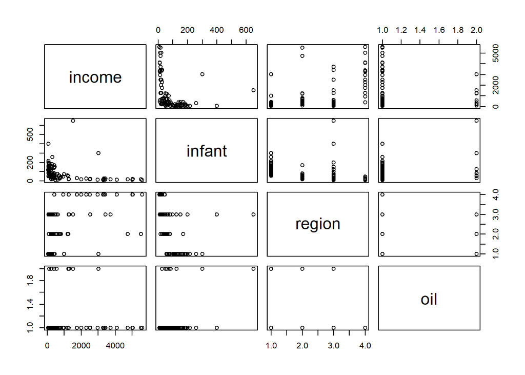

```r
pairs(Leinhardt)
```

We’ll start with a simple linear regression model that relates infant mortality to per capita income.

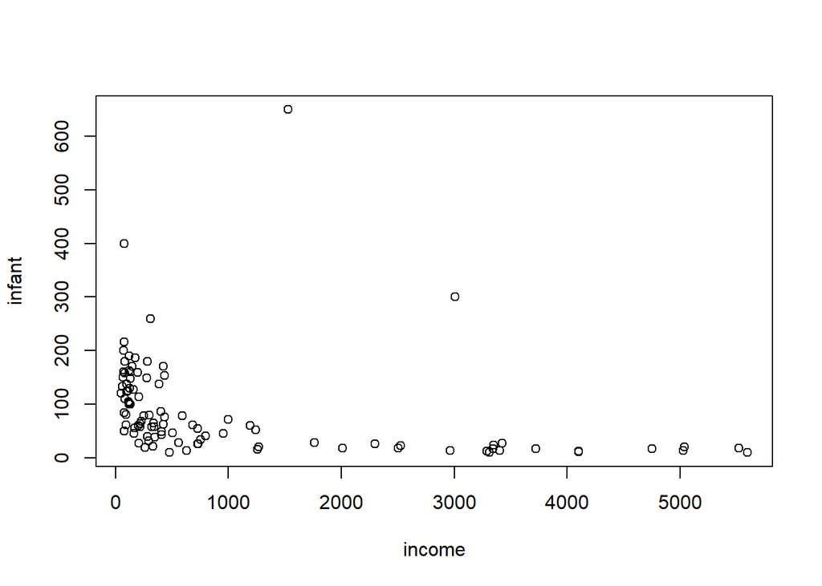

```r
plot(infant ~ income, data=Leinhardt)
```

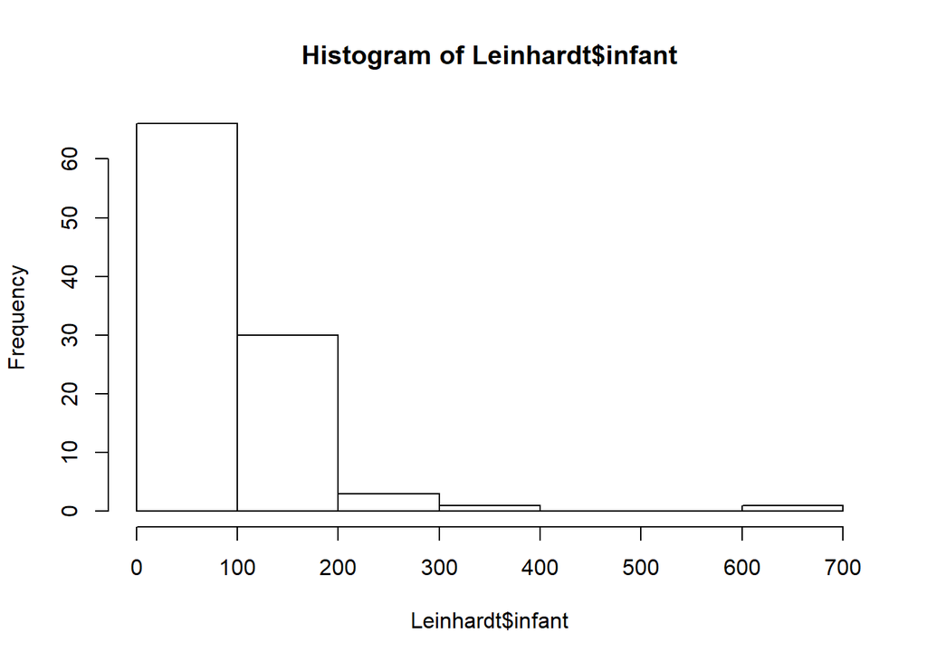

```r
hist(Leinhardt$infant)
```

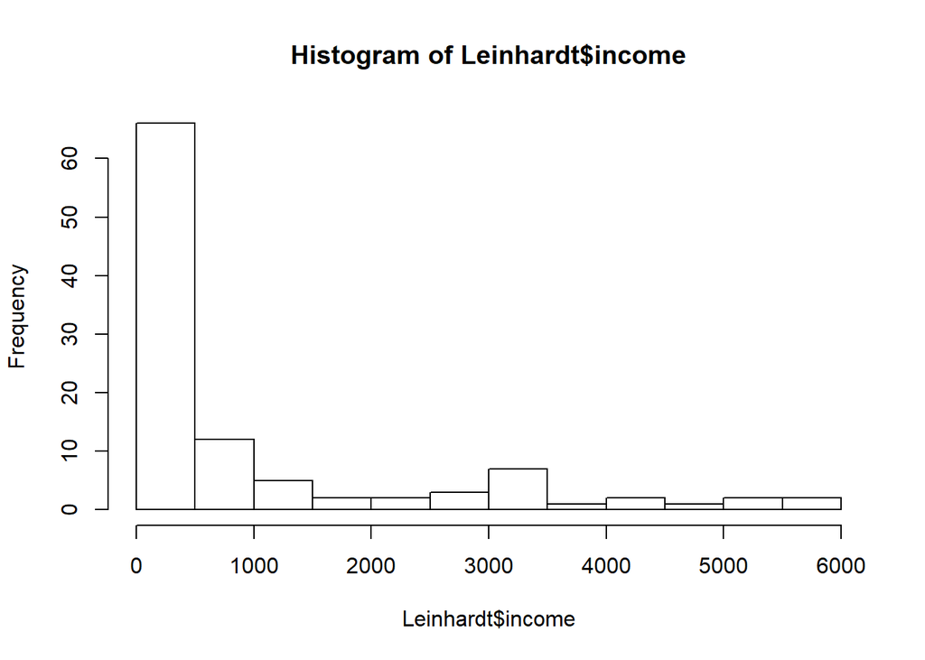

```r
hist(Leinhardt$income)
```

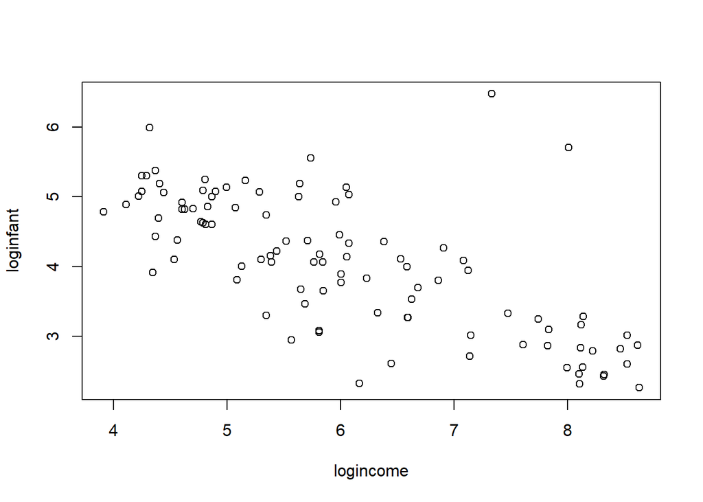

```r
Leinhardt$loginfant = log(Leinhardt$infant)
Leinhardt$logincome = log(Leinhardt$income)

plot(loginfant ~ logincome, data=Leinhardt)
```

Since infant mortality and per capita income are positive and right-skewed quantities, we consider modeling them on the logarithmic scale. A linear model appears much more appropriate on this scale.

#### Modeling

The reference Bayesian analysis (with a noninformative prior) is available directly in R.

```r
lmod = lm(loginfant ~ logincome, data=Leinhardt)
summary(lmod)
```

```
##
## Call:
## lm(formula = loginfant ~ logincome, data = Leinhardt)
##
## Residuals:
##      Min       1Q   Median       3Q      Max
## -1.66694 -0.42779 -0.02649  0.30441  3.08415
##
## Coefficients:
##             Estimate Std. Error t value Pr(>|t|)
## (Intercept)  7.14582    0.31654  22.575   <2e-16 ***
## logincome   -0.51179    0.05122  -9.992   <2e-16 ***
## ---
## Signif. codes:  0 '***' 0.001 '**' 0.01 '*' 0.05 '.' 0.1 ' ' 1
##
## Residual standard error: 0.6867 on 99 degrees of freedom
##   (4 observations deleted due to missingness)
## Multiple R-squared:  0.5021, Adjusted R-squared:  0.4971
## F-statistic: 99.84 on 1 and 99 DF,  p-value: < 2.2e-16
```

### Leson 7.3

#### Model in JAGS

Now we’ll fit this model in JAGS. A few countries have missing values, and for simplicity, we will omit those.

```r
dat = na.omit(Leinhardt)

library("rjags")
```

Pour rappel, on modèlise les modèles JAGS comme un modèle hiérarchique, on commence par le haut (posterior distribution) pour finir par les prior.

On appelle la loi normal $y_i| \mu ~ N(\mu,prec)$, le second paramètre est la précision et non pas la variance classique. On va aussi appeler le second paramètre $E[X]=\beta_0 + \beta_1 * log\_income_i$

Le symbole ~ signifie que la valeur suit une lois de probabilité.

On va ensuite tirer les priors pour b qui suivent une lois normale

et enfin une précision avec gamma.

On dit que la précision est $\taux = 1/ \sigma^2$, on la définit aussi comme “la distribution gamma peut être utilisé comme conjugate prior precision”, peut être plus interssant car il explique comment les données sont concentrés autours de la moyenne, plutôt qu’une mesure de dispersion

```r
mod1_string = " model {
    for (i in 1:n) {
        y[i] ~ dnorm(mu[i], prec)
        mu[i] = b[1] + b[2]*log_income[i]
    }

    for (i in 1:2) {
        b[i] ~ dnorm(0.0, 1.0/1.0e6)
    }

    prec ~ dgamma(5/2.0, 5*10.0/2.0)
    sig2 = 1.0 / prec
    sig = sqrt(sig2)
} "

set.seed(72)
# on définit les inputs
data1_jags = list(y=dat$loginfant, n=nrow(dat),
              log_income=dat$logincome)
# on écrit les paramètres à estimer
params1 = c("b", "sig")

# on définit une fonction pour définir les valeurs à t=0
inits1 = function() {
    inits = list("b"=rnorm(2,0.0,100.0), "prec"=rgamma(1,1.0,1.0))
}
# on va compiler le modéle, l'argument 1 est le modèle en string, qui est généralement dans un fichier
# mais ici on l'a déjà codé en haut, on doit écrire textConnection
# le second param est les donnée, puis les données initiales et le nombre de chaînes
mod1 = jags.model(textConnection(mod1_string), data=data1_jags, inits=inits1, n.chains=3)
# 3. Run the MCMC sampler
# 2nd param: combien d'itérations on veut pr l'update, ici 1000
# il lance le mcmc snas sauvegarder la chaînes
update(mod1, 1000) # burn-in

# on doit lui dire combien d'itérations MCMC on veut
# ca va en gros continuer après les 1000 itérations déjà faite
mod1_sim = coda.samples(model=mod1,
                        variable.names=params1,
                        n.iter=5000)

mod1_csim = do.call(rbind, mod1_sim) # combine multiple chains
```

### Leson 7.3

#### MCMC convergence

Before we check the inferences from the model, we should perform convergence diagnostics for our Markov chains.

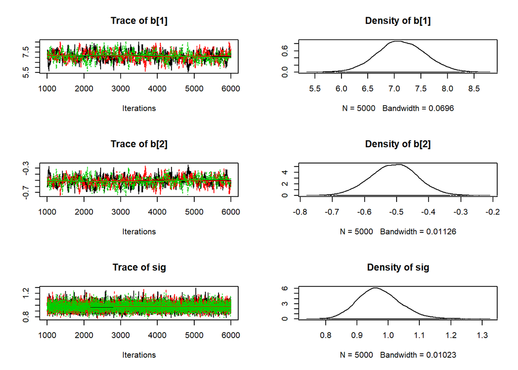

```r
plot(mod1_sim)
```

```r
gelman.diag(mod1_sim)
```

```
## Potential scale reduction factors:
##
##      Point est. Upper C.I.
## b[1]          1          1
## b[2]          1          1
## sig           1          1
##
## Multivariate psrf
##
## 1
```

```r
autocorr.diag(mod1_sim)
```

```
##              b[1]       b[2]          sig
## Lag 0  1.00000000 1.00000000  1.000000000
## Lag 1  0.95233280 0.95292304  0.008801917
## Lag 5  0.77985611 0.78126194  0.016720871
## Lag 10 0.59841031 0.59871795  0.007907772
## Lag 50 0.07248164 0.07056101 -0.010287545
```

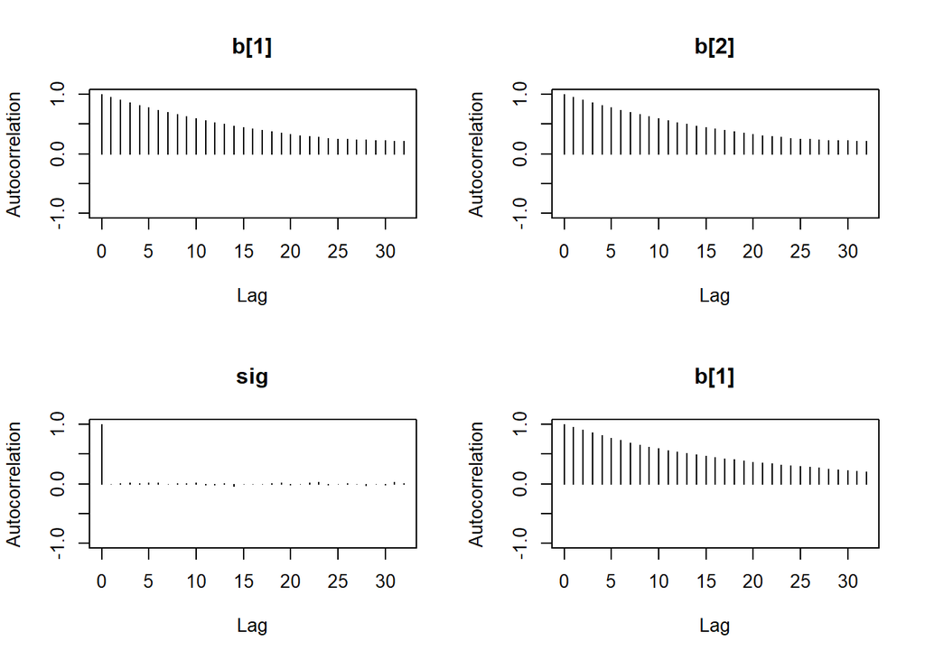

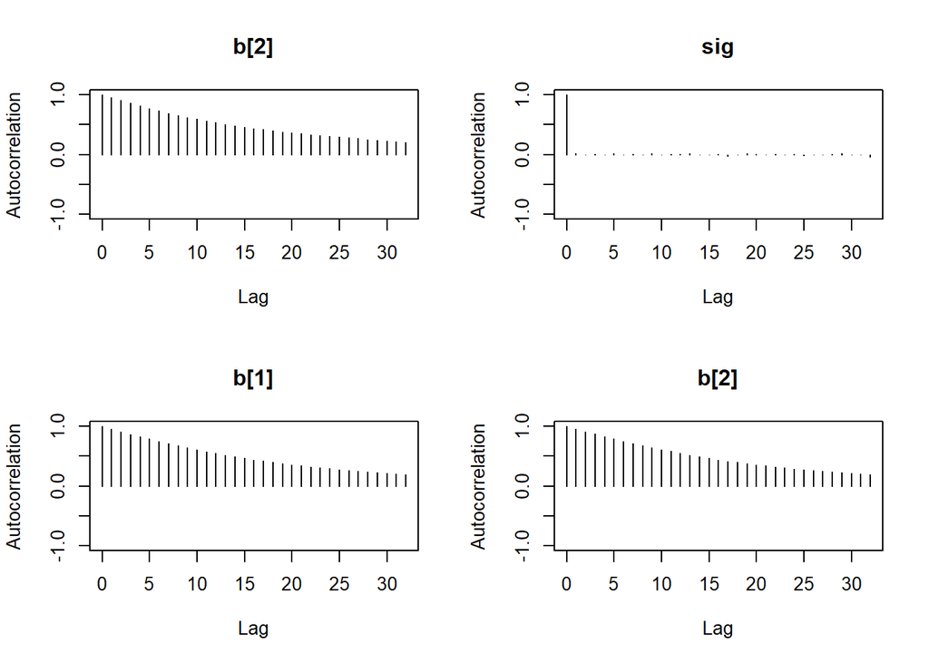

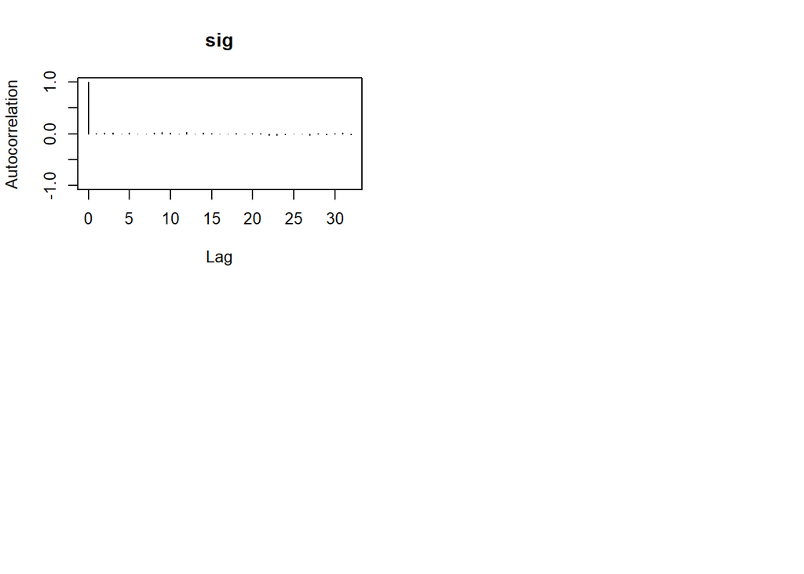

```r
autocorr.plot(mod1_sim)
```

```r
effectiveSize(mod1_sim)
```

```
##       b[1]       b[2]        sig
##   366.1625   361.5211 14791.4578
```

We can get a posterior summary of the parameters in our model.

```r
summary(mod1_sim)
```

```
##
## Iterations = 1001:6000
## Thinning interval = 1
## Number of chains = 3
## Sample size per chain = 5000
##
## 1. Empirical mean and standard deviation for each variable,
##    plus standard error of the mean:
##
##         Mean      SD  Naive SE Time-series SE
## b[1]  7.1276 0.44930 0.0036685      0.0234811
## b[2] -0.5089 0.07271 0.0005937      0.0038245
## sig   0.9713 0.06736 0.0005500      0.0005539
##
## 2. Quantiles for each variable:
##
##         2.5%     25%     50%     75%   97.5%
## b[1]  6.2583  6.8268  7.1191  7.4314  8.0163
## b[2] -0.6523 -0.5578 -0.5076 -0.4598 -0.3672
## sig   0.8502  0.9246  0.9670  1.0131  1.1149
```

Don’t forget that these results are for a regression model relating the logarithm of infant mortality to the logarithm of income.

#### Residual checks

Checking residuals (the difference between the response and the model’s prediction for that value) is important with linear models since residuals can reveal violations of the assumptions we made to specify the model. In particular, we are looking for any sign that the model is not linear, normally distributed, or that the observations are not independent (conditional on covariates).

First, let’s look at what would have happened if we fit the reference linear model to the un-transformed variables.

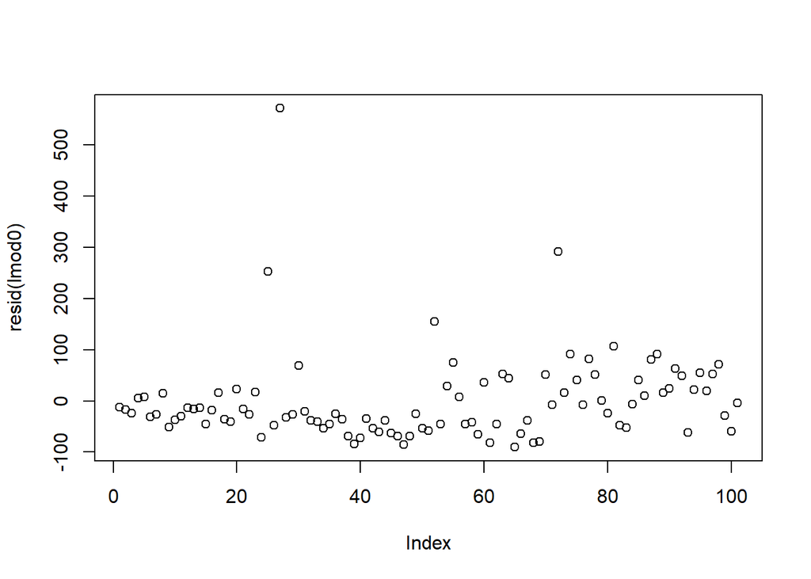

```r
lmod0 = lm(infant ~ income, data=Leinhardt)
plot(resid(lmod0)) # to check independence (looks okay)
```

On voit que les donées semblent bien dispersé

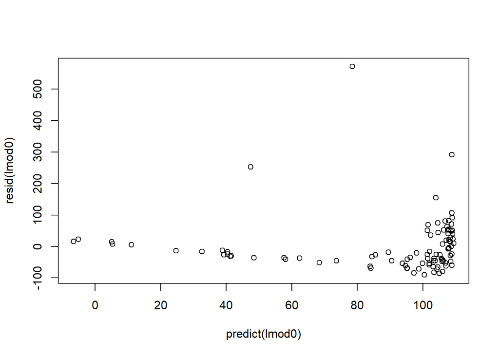

```r
plot(predict(lmod0), resid(lmod0)) # to check for linearity, constant variance (looks bad)
```

Dans ce cas cas le modèle est très mauvais, pour les faibles prédictions la variance est faible puis elle explose vers les prédictions de 100

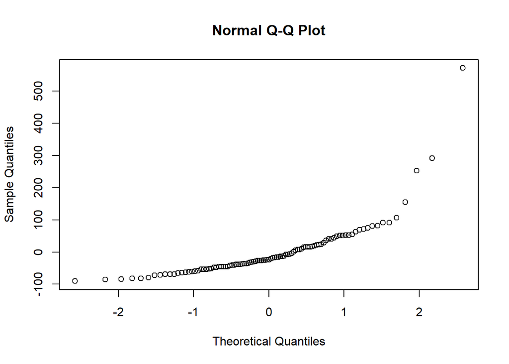

```r
qqnorm(resid(lmod0)) # to check Normality assumption (we want this to be a straight line)
```

Now let’s return to our model fit to the log-transformed variables. In a Bayesian model, we have distributions for residuals, but we’ll simplify and look only at the residuals evaluated at the posterior mean of the parameters.

```r
X = cbind(rep(1.0, data1_jags$n), data1_jags$log_income)
head(X)
```

```
##      [,1]     [,2]
## [1,]    1 8.139149
## [2,]    1 8.116716
## [3,]    1 8.115521
## [4,]    1 8.466110
## [5,]    1 8.522976
## [6,]    1 8.105308
```

```r
(pm_params1 = colMeans(mod1_csim)) # posterior mean
```

```
##       b[1]       b[2]        sig
##  7.1276393 -0.5088900  0.9713436
```

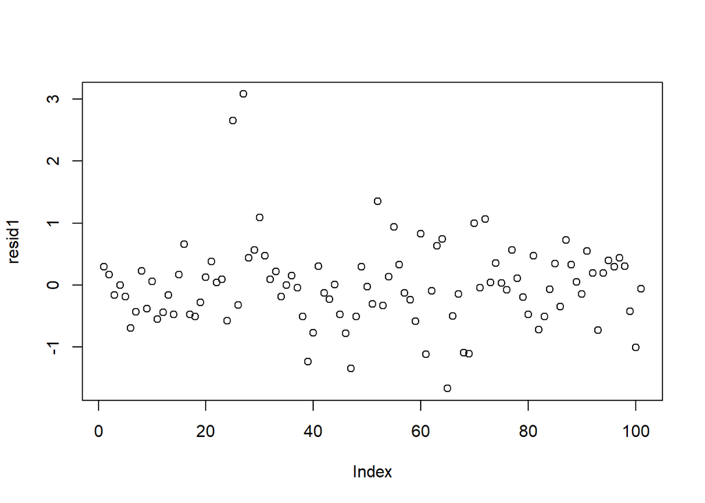

```r
yhat1 = drop(X %*% pm_params1[1:2])
resid1 = data1_jags$y - yhat1
plot(resid1) # against data index
```

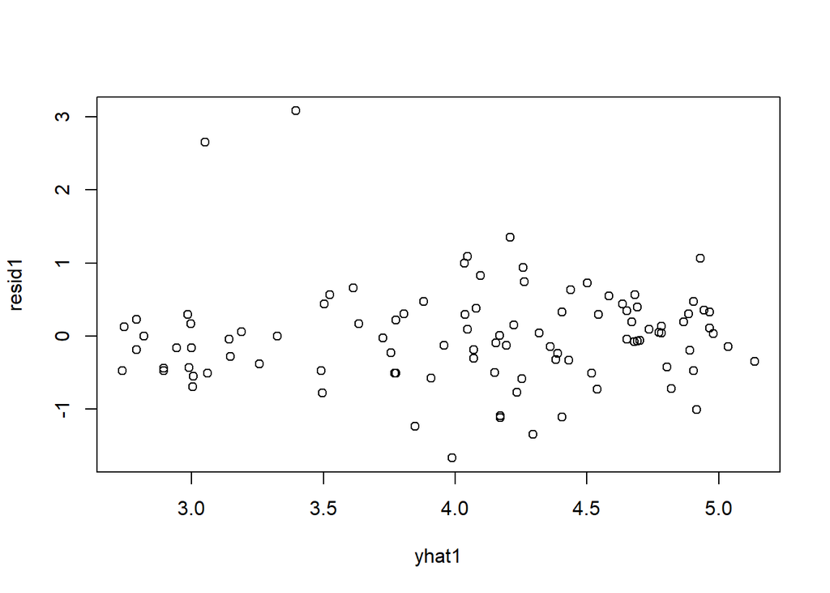

```r
plot(yhat1, resid1) # against predicted values
```

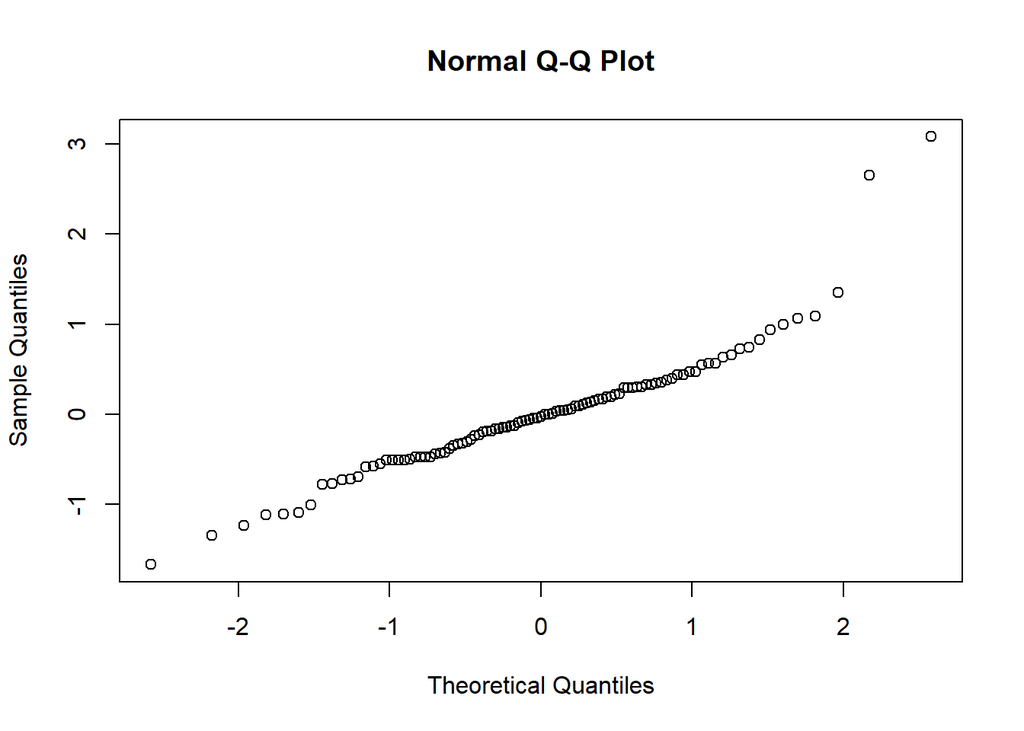

```r
qqnorm(resid1) # checking normality of residuals
```

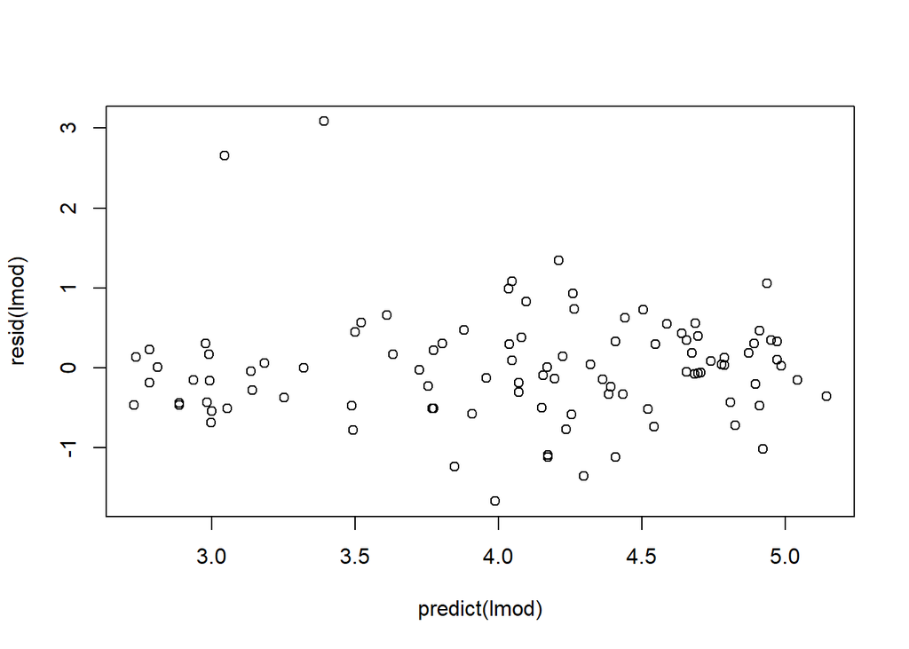

```r
plot(predict(lmod), resid(lmod)) # to compare with reference linear model
```

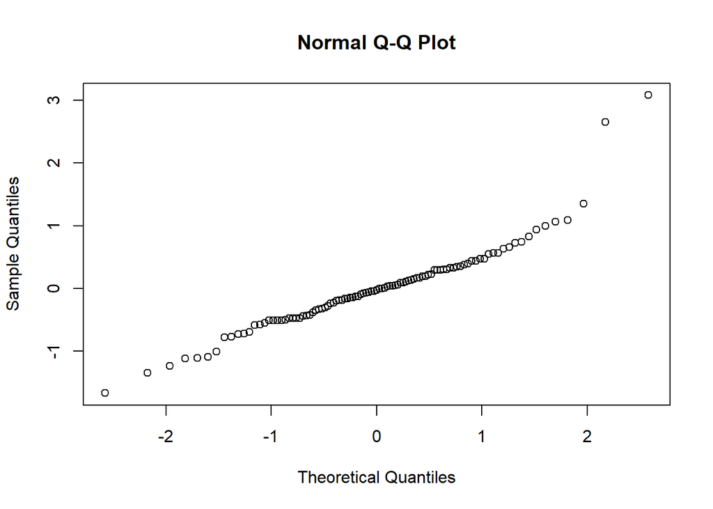

```r
qqnorm(resid1) # checking normality of residuals
```

```r
rownames(dat)[order(resid1, decreasing=TRUE)[1:5]] # which countries have the largest positive residuals?
```

```
## [1] "Saudi.Arabia" "Libya"        "Zambia"       "Brazil"
## [5] "Afganistan"
```

The residuals look pretty good here (no patterns, shapes) except for two strong outliers, Saudi Arabia and Libya. When outliers appear, it is a good idea to double check that they are not just errors in data entry. If the values are correct, you may reconsider whether these data points really are representative of the data you are trying to model. If you conclude that they are not (for example, they were recorded on different years), you may be able to justify dropping these data points from the data set.

If you conclude that the outliers are part of data and should not be removed, we have several modeling options to accommodate them. We will address these in the next segment.

### Quizz lesson 7 part A:

```r
library(car)
data("Anscombe")
head(Anscombe)
```

```
##    education income young urban
## ME       189   2824 350.7   508
## NH       169   3259 345.9   564
## VT       230   3072 348.5   322
## MA       168   3835 335.3   846
## RI       180   3549 327.1   871
## CT       193   4256 341.0   774
```

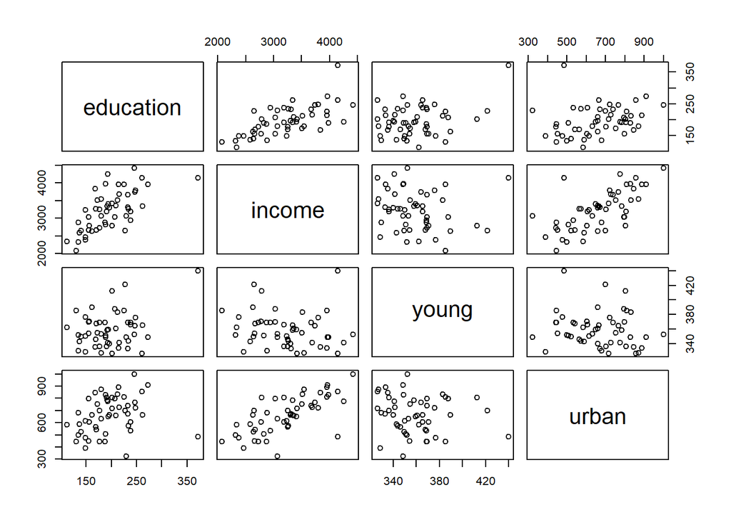

```r
pairs(Anscombe)
```

On peut lire que education et income semble fortement corrélés

```r
lmod = lm(education ~ ., data=Anscombe)
summary(lmod)
```

```
##
## Call:
## lm(formula = education ~ ., data = Anscombe)
##
## Residuals:
##     Min      1Q  Median      3Q     Max
## -60.240 -15.738  -1.156  15.883  51.380
##
## Coefficients:
##               Estimate Std. Error t value Pr(>|t|)
## (Intercept) -2.868e+02  6.492e+01  -4.418 5.82e-05 ***
## income       8.065e-02  9.299e-03   8.674 2.56e-11 ***
## young        8.173e-01  1.598e-01   5.115 5.69e-06 ***
## urban       -1.058e-01  3.428e-02  -3.086  0.00339 **
## ---
## Signif. codes:  0 '***' 0.001 '**' 0.01 '*' 0.05 '.' 0.1 ' ' 1
##
## Residual standard error: 26.69 on 47 degrees of freedom
## Multiple R-squared:  0.6896, Adjusted R-squared:  0.6698
## F-statistic: 34.81 on 3 and 47 DF,  p-value: 5.337e-12
```

We run it with JAGS this time:

```r
library("rjags")

mod_string = " model {
    for (i in 1:length(education)) {
        education[i] ~ dnorm(mu[i], prec)
        mu[i] = b0 + b[1]*income[i] + b[2]*young[i] + b[3]*urban[i]
    }

    b0 ~ dnorm(0.0, 1.0/1.0e6)
    for (i in 1:3) {
        b[i] ~ dnorm(0.0, 1.0/1.0e6)
    }

    prec ~ dgamma(1.0/2.0, 1.0*1500.0/2.0)
        ## Initial guess of variance based on overall
        ## variance of education variable. Uses low prior
        ## effective sample size. Technically, this is not
        ## a true 'prior', but it is not very informative.
    sig2 = 1.0 / prec
    sig = sqrt(sig2)
} "

set.seed(64)
data_jags = as.list(Anscombe)

params1 = c("b","sig")

inits1 = function(){
  inits = list("b"=rnorm(3,0.0,100.0), "prec"=rgamma(1,1.0,1.0))
}

mod1 = jags.model(textConnection(mod_string),
                  data = data_jags,
                  inits=inits1,
                  n.chains=3)
update(mod1, 1000) # burn-in

mod1_sim = coda.samples(model=mod1,
                        variable.names=params1,
                        n.iter=10000)

mod1_csim = do.call(rbind, mod1_sim) # combine multiple chains
```

[figure not shown]

```r
plot(mod1_sim)
```

```r
gelman.diag(mod1_sim)
```

```
## Potential scale reduction factors:
##
##      Point est. Upper C.I.
## b[1]       1.03       1.11
## b[2]       1.15       1.44
## b[3]       1.00       1.01
## sig        1.00       1.00
##
## Multivariate psrf
##
## 1.13
```

```r
autocorr.diag(mod1_sim)
```

```
##             b[1]      b[2]      b[3]        sig
## Lag 0  1.0000000 1.0000000 1.0000000 1.00000000
## Lag 1  0.9848157 0.9963617 0.9729252 0.09040605
## Lag 5  0.9291235 0.9826493 0.8761374 0.04660588
## Lag 10 0.8708005 0.9676852 0.7764255 0.03792686
## Lag 50 0.5557442 0.8727651 0.3666971 0.03006977
```

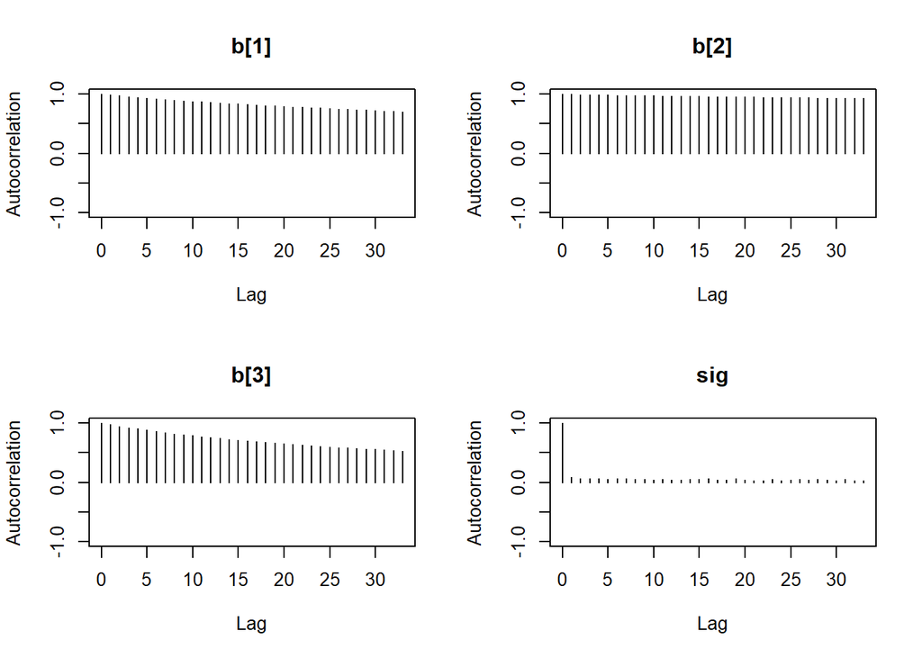

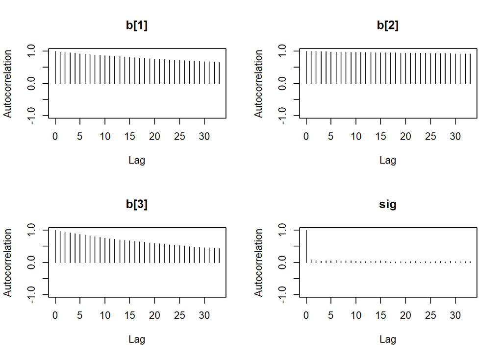

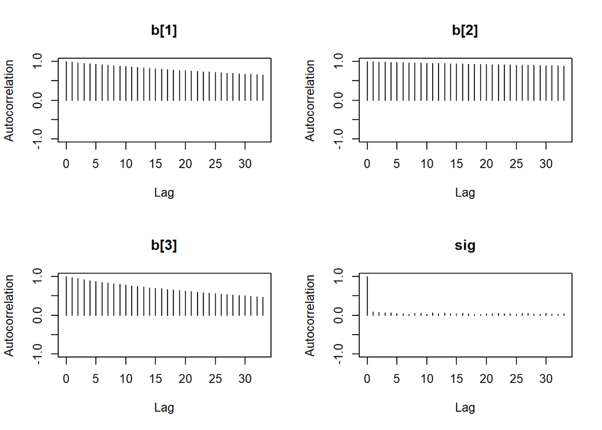

```r
autocorr.plot(mod1_sim)
```

On peut noter que l’autocorrélation pour les trois variables bi est très importante, il faudrait augmenter le nombre d’itérations, je suis passé de 5000 à 100.000 pas de changement majeur

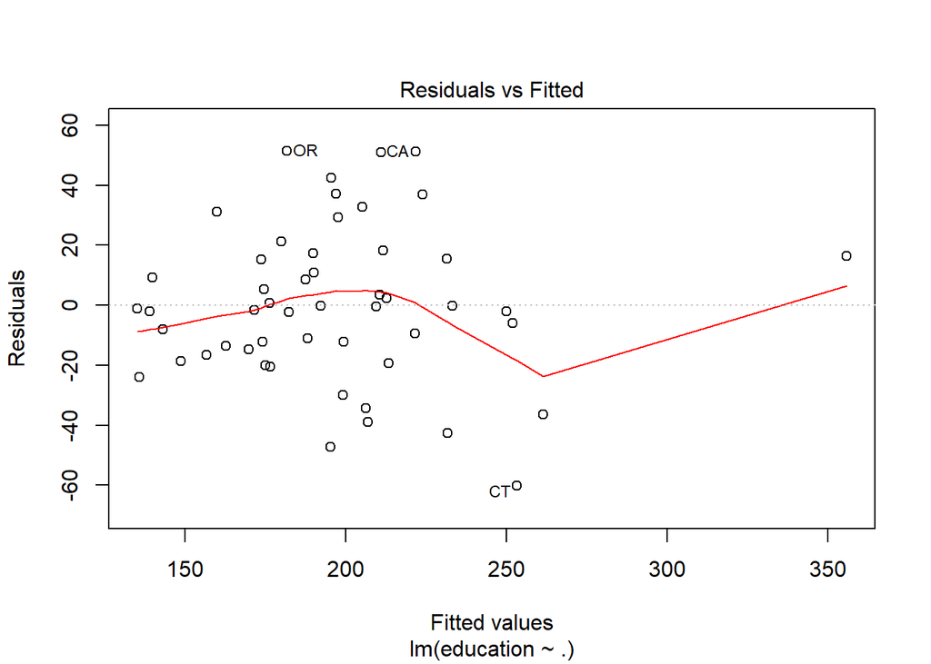

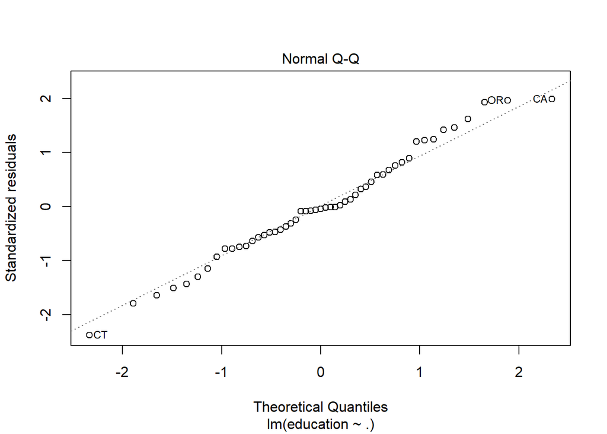

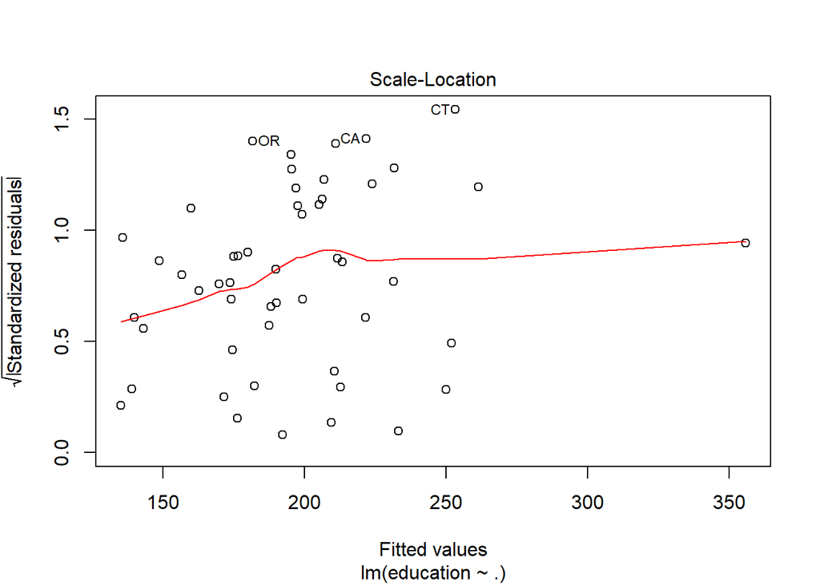

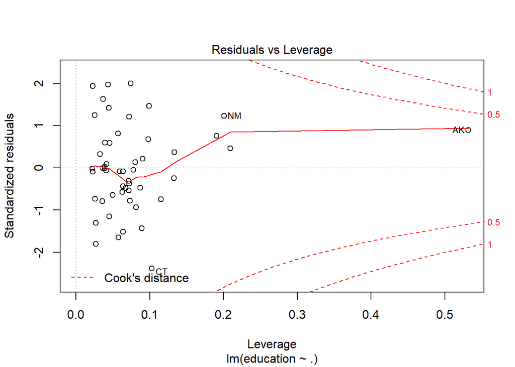

```r
plot(lmod)
```

```r
# here mod_lm is the object saved when you run lm()
```

### Leson 7.5

In the previous segment, we saw two outliers in the model relating the logarithm of infant mortality to the logarithm of income. Here we will discuss options for when we conclude that these outliers belong in the data set.

#### Additional covariates

The first approach is to look for additional covariates (or explanatory variables) that may be able to explain the outliers. For example, there could be a number of variables that provide information about infant mortality above and beyond what income provides as an explanation

Looking back at our data, there are two variables we haven’t used yet: region and oil. The oil variable indicates oil-exporting countries. Both Saudi Arabia and Libya are oil-exporting countries, so perhaps this might explain part of the anomaly.

```r
library("rjags")

# we include the indicator variable is_oil (new_variable), ajout dummy variable
mod2_string = " model {
    for (i in 1:length(y)) {
        y[i] ~ dnorm(mu[i], prec)
        mu[i] = b[1] + b[2]*log_income[i] + b[3]*is_oil[i]
    }

    for (i in 1:3) {
        b[i] ~ dnorm(0.0, 1.0/1.0e6)
    }

    prec ~ dgamma(5/2.0, 5*10.0/2.0)
    sig = sqrt( 1.0 / prec )
} "


set.seed(73)
# nouveauté: on crée une variable indicator, avec yes et no (yes=1,no=0)
data2_jags = list(y=dat$loginfant, log_income=dat$logincome,
                  is_oil=as.numeric(dat$oil=="yes"))
data2_jags$is_oil
```

```
##   [1] 0 0 0 0 0 0 0 0 0 0 0 0 0 0 0 0 0 0 0 0 1 1 1 1 1 1 1 1 0 0 0 0 0 0 0
##  [36] 0 0 0 0 0 0 0 0 0 0 0 0 0 0 0 0 0 0 0 0 0 0 0 0 0 0 0 0 0 0 0 0 0 0 0
##  [71] 0 0 0 0 0 0 0 0 0 0 0 0 0 0 0 0 0 0 0 0 0 0 0 0 0 0 0 0 0 0 0
```

```r
params2 = c("b", "sig")

inits2 = function() {
    inits = list("b"=rnorm(3,0.0,100.0), "prec"=rgamma(1,1.0,1.0))
}

mod2 = jags.model(textConnection(mod2_string), data=data2_jags, inits=inits2, n.chains=3)
# 1000 iterations de burn in
update(mod2, 1e3) # burn-in

mod2_sim = coda.samples(model=mod2,
                        variable.names=params2,
                        n.iter=5e3)

mod2_csim = as.mcmc(do.call(rbind, mod2_sim)) # combine multiple chains
```

As usual, check the convergence diagnostics.

```r
summary(mod2_sim)
```

```
##
## Iterations = 1001:6000
## Thinning interval = 1
## Number of chains = 3
## Sample size per chain = 5000
##
## 1. Empirical mean and standard deviation for each variable,
##    plus standard error of the mean:
##
##         Mean      SD  Naive SE Time-series SE
## b[1]  7.1285 0.41361 0.0033771      0.0205536
## b[2] -0.5192 0.06698 0.0005469      0.0033449
## b[3]  0.7848 0.35063 0.0028629      0.0030905
## sig   0.9510 0.06747 0.0005509      0.0005563
##
## 2. Quantiles for each variable:
##
##          2.5%     25%     50%     75%   97.5%
## b[1]  6.29693  6.8588  7.1304  7.4037  7.9436
## b[2] -0.65144 -0.5639 -0.5197 -0.4760 -0.3856
## b[3]  0.09521  0.5513  0.7832  1.0183  1.4765
## sig   0.82977  0.9036  0.9476  0.9942  1.0943
```

Remarque: on devrait toujours vérifier la convergence, mais dans ce cas la pour économiser du temps on va regarder d’autres facteurs.

Regardons le posterior chain.

[figure not shown]

```r
plot(mod2_sim)
```

```r
gelman.diag(mod2_sim)
```

```
## Potential scale reduction factors:
##
##      Point est. Upper C.I.
## b[1]          1       1.01
## b[2]          1       1.01
## b[3]          1       1.00
## sig           1       1.00
##
## Multivariate psrf
##
## 1
```

```r
autocorr.diag(mod2_sim)
```

```
##               b[1]        b[2]         b[3]          sig
## Lag 0   1.00000000  1.00000000  1.000000000  1.000000000
## Lag 1   0.94675897  0.94715470  0.084093676  0.020541686
## Lag 5   0.76204513  0.76148142  0.004589118  0.004626244
## Lag 10  0.57202451  0.57191005 -0.003865644  0.013799215
## Lag 50 -0.02987218 -0.02935888 -0.017102539 -0.009965875
```

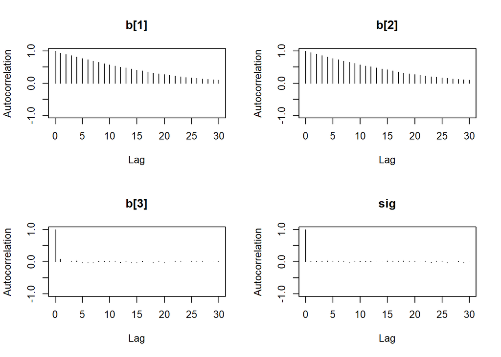

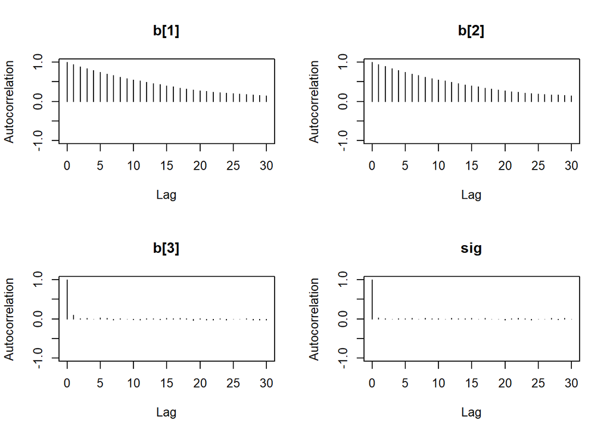

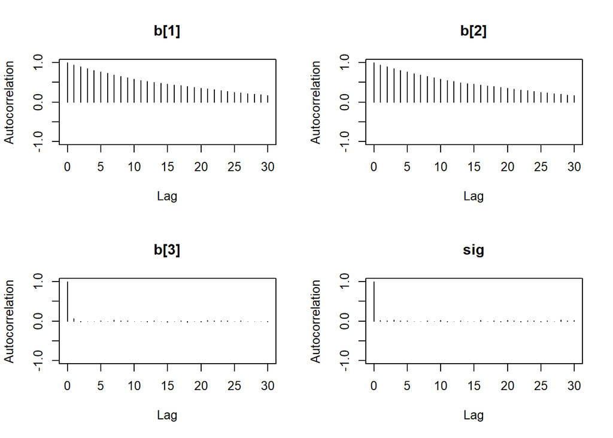

```r
autocorr.plot(mod2_sim)
```

```r
effectiveSize(mod2_sim)
```

```
##       b[1]       b[2]       b[3]        sig
##   404.8523   401.3022 12889.6361 14723.6826
```

We can get a posterior summary of the parameters in our model.

```r
summary(mod2_sim)
```

```
##
## Iterations = 1001:6000
## Thinning interval = 1
## Number of chains = 3
## Sample size per chain = 5000
##
## 1. Empirical mean and standard deviation for each variable,
##    plus standard error of the mean:
##
##         Mean      SD  Naive SE Time-series SE
## b[1]  7.1285 0.41361 0.0033771      0.0205536
## b[2] -0.5192 0.06698 0.0005469      0.0033449
## b[3]  0.7848 0.35063 0.0028629      0.0030905
## sig   0.9510 0.06747 0.0005509      0.0005563
##
## 2. Quantiles for each variable:
##
##          2.5%     25%     50%     75%   97.5%
## b[1]  6.29693  6.8588  7.1304  7.4037  7.9436
## b[2] -0.65144 -0.5639 -0.5197 -0.4760 -0.3856
## b[3]  0.09521  0.5513  0.7832  1.0183  1.4765
## sig   0.82977  0.9036  0.9476  0.9942  1.0943
```

It looks like there is a positive relationship between oil-production and log-infant mortality. Because these data are merely observational, we cannot say that oil-production causes an increase in infant mortality (indeed that most certainly isn’t the case), but we can say that they are positively correlated.

Now let’s check the residuals.

```r
X2 = cbind(rep(1.0, data1_jags$n), data2_jags$log_income, data2_jags$is_oil)
head(X2)
```

```
##      [,1]     [,2] [,3]
## [1,]    1 8.139149    0
## [2,]    1 8.116716    0
## [3,]    1 8.115521    0
## [4,]    1 8.466110    0
## [5,]    1 8.522976    0
## [6,]    1 8.105308    0
```

```r
(pm_params2 = colMeans(mod2_csim)) # posterior mean
```

```
##       b[1]       b[2]       b[3]        sig
##  7.1284764 -0.5192069  0.7848175  0.9509822
```

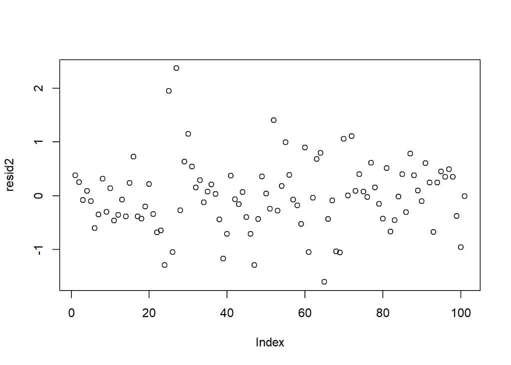

```r
yhat2 = drop(X2 %*% pm_params2[1:3])
resid2 = data2_jags$y - yhat2
plot(resid2) # against data index
```

on va comparer les residuals du nouveau modèle et du précédent

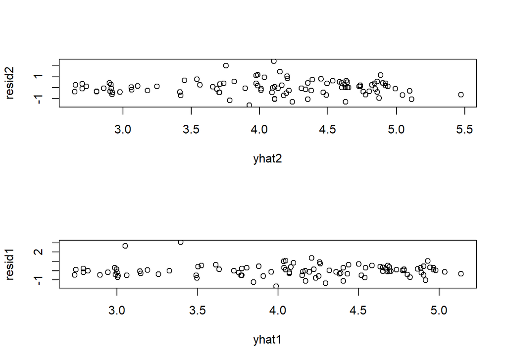

```r
par(mfrow=c(2,1))
plot(yhat2, resid2) # against predicted values
plot(yhat1, resid1) # residuals from the first model
```

meilleur résiduals , les anciens outliesr sont plus dans le stream des données, on a un sd de 0.64, les outliers sont a plus que 2sd de la moyenne, 0.64 signifie 3 sd au dessus de la moyenne

```r
sd(resid2) # standard deviation of residuals
```

```
## [1] 0.6488759
```

These look much better, although the residuals for Saudi Arabia and Libya are still more than three standard deviations away from the mean of the residuals. We might consider adding the other covariate region, but instead let’s look at another option when we are faced with strong outliers.

#### t likelihood

Let’s consider changing the likelihood. The normal likelihood has thin tails (almost all of the probability is concentrated within the first few standard deviations from the mean). This does not accommodate outliers well. Consequently, models with the normal likelihood might be overly-influenced by outliers. Recall that the $t$ distribution is similar to the normal distribution, but it has thicker tails which can accommodate outliers.

The $t$ linear model might look something like this. Notice that the tt distribution has three parameters, including a positive “degrees of freedom” parameter. The smaller the degrees of freedom, the heavier the tails of the distribution. We might fix the degrees of freedom to some number, or we can assign it a prior distribution.

```r
mod3_string = " model {
    for (i in 1:length(y)) {
        params:taux=inverse scale parameter
        df: degrees of freedom, the smaller the degrees the heavier the tail of the t distrib
        y[i] ~ dt( mu[i], tau, df )
        mu[i] = b[1] + b[2]*log_income[i] + b[3]*is_oil[i]
    }

    for (i in 1:3) {
        b[i] ~ dnorm(0.0, 1.0/1.0e6)
    }

    df = nu + 2.0 # we want degrees of freedom > 2 to guarantee existence of mean and variance
# les degrees of freedom doivent être positif donc on leur donnera une loi exponentiel
    nu ~ dexp(1.0)

    tau ~ dgamma(5/2.0, 5*10.0/2.0) # tau is close to, but not equal to the precision
# inverse scale: related to the sig
    sig = sqrt( 1.0 / tau * df / (df - 2.0) ) # standard deviation of errors
} "
```

As a side note: we should be aware that the prior df=exo(1.0) does not have a mean and a variance if the degrees of freedom are less than 2, that can happen under this model, if we want to force the $t$ to have a degrees of freedom we can define a new variable here, $df = \nu + 2.0$.  
We will leave it up to you to fit this model.

### Leson 7.6

#### Compare models using Deviance Information Criterion

We have now proposed three different models. How do we compare their performance on our data? In the previous course, we discussed estimating parameters in models using the maximum likelihood method. Similarly, we can choose between competing models using the same idea.

We will use a quantity known as the deviance information criterion (DIC). It essentially calculates the posterior mean of the log-likelihood and adds a penalty for model complexity.

Let’s calculate the DIC for our first two models:

```r
# it samples from a posterior distribution, so we need iterations
dic.samples(mod1, n.iter=1e3)
```

```
## Mean deviance:  480.6
## penalty 4.893
## Penalized deviance: 485.5
```

and the second model where we add oil production.

```r
# we added oil for this model
dic.samples(mod2, n.iter=1e3)
```

```
## Mean deviance:  225.4
## penalty 4.044
## Penalized deviance: 229.4
```

The first number is the Monte Carlo estimated posterior mean deviance, which equals $-2$ times the log-likelihood (plus a constant that will be irrelevant for comparing models). Because of that $-2$ factor, a smaller deviance means a higher likelihood.

We encourage you to explore different model specifications and compare their fit to the data using DIC. Wikipedia provides a good introduction to DIC and we can find more details about the JAGS implementation through the rjags package documentation by entering ?dic.samples in the R console. We might try fitting the model with the t model, and compare the results

### Quizz sur DIC

```r
# we added oil for this model
dic.samples(mod1, n.iter=1e5)
```

```
## Mean deviance:  481
## penalty 5.298
## Penalized deviance: 486.3
```

on va comparer deux modèles:

1. On enléve le prédictor urban
2. En plus d’enlever urban on va rajouter un interaction terme $\beta_3 \times income \times youth$

Faire un fit avec JAGS et calculer le DIC pour chacun. Si la performance de prédiction est notre critère, quel modèle réussi le mieux ?

1. modèle 1:

```r
# we added oil for this model
mod_string = " model {
    for (i in 1:length(education)) {
        education[i] ~ dnorm(mu[i], prec)
        mu[i] = b0 + b[1]*income[i] + b[2]*young[i]
    }

    b0 ~ ddexp(0.0, 2.0)
    for (i in 1:2) {
        b[i] ~ ddexp(0.0, 2.0)
    }

    prec ~ dgamma(1.0/2.0, 1.0*1500.0/2.0)
        ## Initial guess of variance based on overall
        ## variance of education variable. Uses low prior
        ## effective sample size. Technically, this is not
        ## a true 'prior', but it is not very informative.
    sig2 = 1.0 / prec
    sig = sqrt(sig2)
} "

set.seed(64)
data_jags = as.list(Anscombe)

params1 = c("b","sig")

inits1 = function(){
  inits = list("b"=rnorm(2,0.0,100.0), "prec"=rgamma(1,1.0,1.0))
}

mod_without_urban = jags.model(textConnection(mod_string),
                  data = data_jags,
                  inits=inits1,
                  n.chains=3)
dic.samples(mod_without_urban, n.iter=1e5)
```

```
## Mean deviance:  504.6
## penalty 3.053
## Penalized deviance: 507.6
```

```r
# we added oil for this model
mod_string = " model {
    for (i in 1:length(education)) {
        education[i] ~ dnorm(mu[i], prec)
        mu[i] = b0 + b[1]*income[i] + b[2]*young[i] + b[3] * income[i] * young[i]
    }

    b0 ~ dnorm(0.0, 1.0/1.0e6)
    for (i in 1:3) {
        b[i] ~ dnorm(0.0, 1.0/1.0e6)
    }

    prec ~ dgamma(1.0/2.0, 1.0*1500.0/2.0)
        ## Initial guess of variance based on overall
        ## variance of education variable. Uses low prior
        ## effective sample size. Technically, this is not
        ## a true 'prior', but it is not very informative.
    sig2 = 1.0 / prec
    sig = sqrt(sig2)
} "

set.seed(64)
data_jags = as.list(Anscombe)

params1 = c("b","sig")

inits1 = function(){
  inits = list("b"=rnorm(3,0.0,100.0), "prec"=rgamma(1,1.0,1.0))
}

mod_interaction_without_urban = jags.model(textConnection(mod_string),
                  data = data_jags,
                  inits=inits1,
                  n.chains=3)
dic.samples(mod_interaction_without_urban, n.iter=1e5)
```

```
## Mean deviance:  493.3
## penalty 4344
## Penalized deviance: 4837
```

Le modèle chois est donc le premier, qui a la plus faible DIC

```r
summary(mod1_sim)
```

```
##
## Iterations = 1001:11000
## Thinning interval = 1
## Number of chains = 3
## Sample size per chain = 10000
##
## 1. Empirical mean and standard deviation for each variable,
##    plus standard error of the mean:
##
##          Mean       SD  Naive SE Time-series SE
## b[1]  0.08004 0.009722 5.613e-05      0.0006695
## b[2]  0.77860 0.185183 1.069e-03      0.0269205
## b[3] -0.10632 0.034690 2.003e-04      0.0017432
## sig  27.53559 2.878149 1.662e-02      0.0390976
##
## 2. Quantiles for each variable:
##
##          2.5%     25%      50%      75%    97.5%
## b[1]  0.06135  0.0733  0.08003  0.08666  0.09902
## b[2]  0.41850  0.6436  0.78478  0.91469  1.12356
## b[3] -0.17499 -0.1298 -0.10533 -0.08260 -0.04032
## sig  22.60396 25.5120 27.28755 29.29793 33.87179
```